# Report

Arsyad, Athilah, Jen Lyn, Rongqing, Yunjia

3/25/2020

```r
library(kernlab)
```

CONTENTS: 1. Introduction  
2. Data Exploration  
3. Prediction Model:  
+ Logistic Regression Model  
+ KNN Model  
+ SVM Model  
+ ANN Model  
+ Decision Tree  
+ Boosting  
+ Bagging  
+ Stacked Model  
4. Conclusion

## Introduction

Pet adoption problem has recently drawn people’s attention, as more people want to adopt a pet during the global pandemic. It is important for animal shelters and related business to predict how soon pets can find their owner. We want to build data models using R to help with the predictions. The dataset to moltivate this study is from https://www.kaggle.com/c/petfinder-adoption-prediction/data, which contain data for cats and dogs. Specifically, we want to predict how soon a pet can be adopted, based on various features including type, gender, health, etc. We also want to explore the dataset to find if there is anything interesting or surprising.

## Data Exploration

### Interesting Insights

#### What are the most popular names for pets?

```r
pet <- read.csv("train.csv")
library(dplyr)
catbyname <- pet %>% filter(Type == 2 & Name != "" & Name != "No Name")%>% group_by(Name) %>% summarize(total = n(), avg_speed = mean(AdoptionSpeed)) %>% arrange(desc(total)) %>% slice(1:10)
catbyname
```

```
## # A tibble: 10 x 3
##    Name    total avg_speed
##    <fct>   <int>     <dbl>
##  1 Kittens    39      2.59
##  2 Kitty      38      2.29
##  3 Baby       34      2.68
##  4 Mimi       33      2.18
##  5 Kitten     22      2.41
##  6 Ginger     20      2.5
##  7 Tiger      20      2.2
##  8 Kiki       19      2.79
##  9 Snowy      19      2.42
## 10 Blackie    18      2.11
```

10 Most Popular Cats’ Name: Kittens, Kitty, Baby, Mimi, Kitten, Ginger, Tiger, Kiki, Snowy, Blackie

```r
dogbyname <- pet %>% filter(Type == 1 & Name != "" & Name != "No Name") %>% group_by(Name) %>% summarize(total = n(), avg_speed = mean(AdoptionSpeed)) %>% arrange(desc(total)) %>% slice(1:10)
dogbyname
```

```
## # A tibble: 10 x 3
##    Name    total avg_speed
##    <fct>   <int>     <dbl>
##  1 Lucky      48      2.38
##  2 Puppy      45      2.89
##  3 Brownie    44      2.68
##  4 Max        35      2.63
##  5 Baby       32      2.84
##  6 Blackie    31      2.55
##  7 Coco       27      2.78
##  8 Bobby      26      2.62
##  9 Puppies    26      2.42
## 10 Angel      25      2.84
```

10 Most Popular Dogs’ Name: Lucky, Puppy, Brownie, Max, Baby, Blackie, Coco, Bobby, Puppies, Angel

#### What are the names for pets that got adopted faster than others?

```r
catbyspeed <- catbyname %>% arrange(avg_speed)
catbyspeed
```

```
## # A tibble: 10 x 3
##    Name    total avg_speed
##    <fct>   <int>     <dbl>
##  1 Blackie    18      2.11
##  2 Mimi       33      2.18
##  3 Tiger      20      2.2
##  4 Kitty      38      2.29
##  5 Kitten     22      2.41
##  6 Snowy      19      2.42
##  7 Ginger     20      2.5
##  8 Kittens    39      2.59
##  9 Baby       34      2.68
## 10 Kiki       19      2.79
```

Among the top 5 popular names for cats are Blackie, Mimi, Tiger, Kitty and Kitten. Cats with such names were adopted faster than other cats with different names.

```r
dogbyspeed <- dogbyname %>% arrange(avg_speed)
dogbyspeed
```

```
## # A tibble: 10 x 3
##    Name    total avg_speed
##    <fct>   <int>     <dbl>
##  1 Lucky      48      2.38
##  2 Puppies    26      2.42
##  3 Blackie    31      2.55
##  4 Bobby      26      2.62
##  5 Max        35      2.63
##  6 Brownie    44      2.68
##  7 Coco       27      2.78
##  8 Angel      25      2.84
##  9 Baby       32      2.84
## 10 Puppy      45      2.89
```

Among the top 5 popular names for dogs are Lucky, puppies, Blackie, Bobby and Maxare. Dogs with those names were adopted faster than others.

### Data Cleaning

When we considered the data for prediction models, we made slight changes to the data to better fit our models. We did not require the information of the pets’ second breed. Instead, we changed this information to whether the pet is a mixed breed or if it’s a pure breed. We also change the ranges of the response variable, pets’ adoption speed. We were given adoption speed of the following:

0 - Pet was adopted on the same day as it was listed. 1 - Pet was adopted between 1 and 7 days (1st week) after being listed. 2 - Pet was adopted between 8 and 30 days (1st month) after being listed. 3 - Pet was adopted between 31 and 90 days (2nd & 3rd month) after being listed. 4 - No adoption after 100 days of being listed. (There are no pets in this dataset that waited between 90 and 100 days).

We infer that it is more beneficial for animal shelters and animal-related businesses to have information whether pets were adopted within a month or they will be adopted more than a month or never get adopted. This is because we believe that accounting are mostly done monthly. Hence, we change the response variable, pets’ adoption speed, into just 2 groups: 1) Adopted within a month (31 days) or 2) Adopted after a month (31 days) or not adopted.

```r
pet <- read.csv("train.csv")

# Remove unrelated data
pet$Name <- NULL
pet$State <- NULL
pet$RescuerID <- NULL
pet$Description <- NULL
pet$PetID <- NULL

pet$Type <- as.factor(pet$Type)
pet$Breed1 <- as.factor(pet$Breed1)
pet$Gender <- as.factor(pet$Gender)
pet$MaturitySize <- as.factor(pet$MaturitySize)
pet$FurLength <- as.factor(pet$FurLength)
pet$Vaccinated <- as.factor(pet$Vaccinated)
pet$Dewormed <- as.factor(pet$Dewormed)
pet$Sterilized <- as.factor(pet$Sterilized)
pet$Health <- as.factor(pet$Health)

# Classify "mixed breed" pets
pet$mixedbreed <- ifelse(pet$Breed2 == 0, 0,1)
pet$Breed2 <- NULL
pet$mixedbreed <- as.factor(pet$mixedbreed)

# Reclassify the AdoptionSpeed into binary format
pet$AdoptionSpeed <- ifelse(pet$AdoptionSpeed == 0 | pet$AdoptionSpeed == 1 | pet$AdoptionSpeed == 2, 0,1 )

str(pet)
```

```
## 'data.frame':    14993 obs. of  19 variables:
##  $ Type         : Factor w/ 2 levels "1","2": 2 2 1 1 1 2 2 1 2 2 ...
##  $ Age          : int  3 1 1 4 1 3 12 0 2 12 ...
##  $ Breed1       : Factor w/ 176 levels "0","1","3","5",..: 168 137 176 176 176 138 136 176 137 137 ...
##  $ Gender       : Factor w/ 3 levels "1","2","3": 1 1 1 2 1 2 1 2 2 2 ...
##  $ Color1       : int  1 1 2 1 1 5 1 1 6 1 ...
##  $ Color2       : int  7 2 7 2 0 6 0 2 0 7 ...
##  $ Color3       : int  0 0 0 0 0 0 0 7 0 0 ...
##  $ MaturitySize : Factor w/ 4 levels "1","2","3","4": 1 2 2 2 2 2 2 2 2 2 ...
##  $ FurLength    : Factor w/ 3 levels "1","2","3": 1 2 2 1 1 1 3 1 2 2 ...
##  $ Vaccinated   : Factor w/ 3 levels "1","2","3": 2 3 1 1 2 2 2 2 2 3 ...
##  $ Dewormed     : Factor w/ 3 levels "1","2","3": 2 3 1 1 2 2 2 2 2 3 ...
##  $ Sterilized   : Factor w/ 3 levels "1","2","3": 2 3 2 2 2 2 3 2 2 3 ...
##  $ Health       : Factor w/ 3 levels "1","2","3": 1 1 1 1 1 1 1 1 1 1 ...
##  $ Quantity     : int  1 1 1 1 1 1 1 6 1 1 ...
##  $ Fee          : int  100 0 0 150 0 0 300 0 0 0 ...
##  $ VideoAmt     : int  0 0 0 0 0 0 0 0 0 0 ...
##  $ PhotoAmt     : num  1 2 7 8 3 2 3 9 6 2 ...
##  $ AdoptionSpeed: num  0 0 1 0 0 0 0 1 0 1 ...
##  $ mixedbreed   : Factor w/ 2 levels "0","1": 1 1 1 1 1 1 2 1 1 1 ...
```

### Normalizing Data

```r
# Prepare normalized dataset for potential use
pet_random <- pet[sample(nrow(pet)), ]

normalize <- function(x) {
  return((x - min(x)) / (max(x) - min(x)))
}

pet$AdoptionSpeed <- as.factor(pet$AdoptionSpeed)
pet$AdoptSpeed <- pet$AdoptionSpeed
pet$AdoptionSpeed <- NULL

library(dummies)
pet_dummy <- dummy.data.frame(data = pet[,-ncol(pet)],)
pet_norm <- as.data.frame(lapply(pet_dummy, normalize))
pet_norm$AdoptionSpeed <- pet$AdoptSpeed
```

### Preparing Dataset

```r
# Split the dataset for 80% training and 20% testing
set.seed(3)
trainid <- sample(1:nrow(pet_norm), .8*nrow(pet_norm))
train <- pet_norm[trainid,]
test <- pet_norm[-trainid,]
train_labels <- train$AdoptionSpeed
test_labels <- test$AdoptionSpeed
```

## Prediction Model

### Logistic Regression Model

```r
glmodel <- glm(AdoptionSpeed ~. , data = train ,family = "binomial")
# summary(glmodel)

glm_result1<-predict(glmodel, train)
glm_tr <- ifelse(glm_result1>mean(glm_result1),1,0)

glm_result<-predict(glmodel, test)
glm_pred <- ifelse(glm_result>mean(glm_result),1,0)
library(caret)
confusionMatrix(as.factor(glm_pred),test$AdoptionSpeed)
```

```
## Confusion Matrix and Statistics
##
##           Reference
## Prediction   0   1
##          0 968 611
##          1 508 912
##
##                Accuracy : 0.6269
##                  95% CI : (0.6093, 0.6442)
##     No Information Rate : 0.5078
##     P-Value [Acc > NIR] : < 2.2e-16
##
##                   Kappa : 0.2544
##
##  Mcnemar's Test P-Value : 0.002295
##
##             Sensitivity : 0.6558
##             Specificity : 0.5988
##          Pos Pred Value : 0.6130
##          Neg Pred Value : 0.6423
##              Prevalence : 0.4922
##          Detection Rate : 0.3228
##    Detection Prevalence : 0.5265
##       Balanced Accuracy : 0.6273
##
##        'Positive' Class : 0
##
```

```r
glm_acc <- mean(glm_pred ==test_labels)
glm_acc
```

```
## [1] 0.6268756
```

### KNN Model

```r
library(class)
knn_pred <- knn(train = train, test = test,
                      cl = train_labels, k=sqrt(ncol(train)))
knn_tr <- knn(train = train, test = train,
                      cl = train_labels, k=sqrt(ncol(train)))
```

```r
library(gmodels)
CrossTable(x = test_labels, y = knn_pred,
           prop.chisq=FALSE)
```

```
##
##
##    Cell Contents
## |-------------------------|
## |                       N |
## |           N / Row Total |
## |           N / Col Total |
## |         N / Table Total |
## |-------------------------|
##
##
## Total Observations in Table:  2999
##
##
##              | knn_pred
##  test_labels |         0 |         1 | Row Total |
## -------------|-----------|-----------|-----------|
##            0 |      1432 |        44 |      1476 |
##              |     0.970 |     0.030 |     0.492 |
##              |     0.962 |     0.029 |           |
##              |     0.477 |     0.015 |           |
## -------------|-----------|-----------|-----------|
##            1 |        57 |      1466 |      1523 |
##              |     0.037 |     0.963 |     0.508 |
##              |     0.038 |     0.971 |           |
##              |     0.019 |     0.489 |           |
## -------------|-----------|-----------|-----------|
## Column Total |      1489 |      1510 |      2999 |
##              |     0.496 |     0.504 |           |
## -------------|-----------|-----------|-----------|
##
##
```

```r
knn_acc<- mean(knn_pred == test_labels)
knn_acc
```

```
## [1] 0.9663221
```

In building the model, we think the best *k* is the sqrt of the number of variables. In fact, this model produce a high accuracy rate of 0.9663221 for the test data. Further model exploration might be necessary to improve this prediction. (see Stacked Model)

### SVM Model

```r
library(kernlab)
pet_classifier_rbf <- ksvm(AdoptionSpeed ~ Type1 + Type2 + MaturitySize1 + MaturitySize2 + MaturitySize3 + MaturitySize4 + FurLength1 + FurLength2 + FurLength3 + Vaccinated1 + Vaccinated2 + Vaccinated3 + Dewormed1 + Dewormed2 + Dewormed3 + Sterilized1 + Sterilized2 + Sterilized3 + Health1 + Health2 + Health3 + Quantity + PhotoAmt + mixedbreed0 + mixedbreed1, data = train, kernel = "rbfdot")

svm_tr <-predict(pet_classifier_rbf, train) ##
svm_pred <- predict(pet_classifier_rbf, test)

library(gmodels)
CrossTable(x = test_labels, y = svm_pred,
           prop.chisq=FALSE)
```

```
##
##
##    Cell Contents
## |-------------------------|
## |                       N |
## |           N / Row Total |
## |           N / Col Total |
## |         N / Table Total |
## |-------------------------|
##
##
## Total Observations in Table:  2999
##
##
##              | svm_pred
##  test_labels |         0 |         1 | Row Total |
## -------------|-----------|-----------|-----------|
##            0 |      1041 |       435 |      1476 |
##              |     0.705 |     0.295 |     0.492 |
##              |     0.582 |     0.360 |           |
##              |     0.347 |     0.145 |           |
## -------------|-----------|-----------|-----------|
##            1 |       748 |       775 |      1523 |
##              |     0.491 |     0.509 |     0.508 |
##              |     0.418 |     0.640 |           |
##              |     0.249 |     0.258 |           |
## -------------|-----------|-----------|-----------|
## Column Total |      1789 |      1210 |      2999 |
##              |     0.597 |     0.403 |           |
## -------------|-----------|-----------|-----------|
##
##
```

```r
svm_acc<- mean(svm_pred == test$AdoptionSpeed)
svm_acc
```

```
## [1] 0.6055352
```

### ANN Model

```r
# The setup
anndata <- read.csv("train.csv")
anndata$Name <- NULL
anndata$State <- NULL
anndata$RescuerID <- NULL
anndata$Description <- NULL
anndata$PetID <- NULL

anndata$Color1 <- as.factor(anndata$Color1)
anndata$Color2 <- as.factor(anndata$Color2)
anndata$Color3 <- as.factor(anndata$Color3)
anndata$Type <- as.factor(anndata$Type)
anndata$Breed1 <- as.factor(anndata$Breed1)
anndata$Gender <- as.factor(anndata$Gender)
anndata$MaturitySize <- as.factor(anndata$MaturitySize)
anndata$FurLength <- as.factor(anndata$FurLength)
anndata$Vaccinated <- as.factor(anndata$Vaccinated)
anndata$Dewormed <- as.factor(anndata$Dewormed)
anndata$Sterilized <- as.factor(anndata$Sterilized)
anndata$Health <- as.factor(anndata$Health)
anndata$mixedbreed <- ifelse(anndata$Breed2 == 0, 0,1)
anndata$Breed2 <- NULL
anndata$mixedbreed <- as.factor(anndata$mixedbreed)
anndata$AdoptionSpeed <- ifelse(anndata$AdoptionSpeed == 0 | anndata$AdoptionSpeed == 1 | anndata$AdoptionSpeed == 2, 0,1 )

response <- anndata$AdoptionSpeed
anndata$AdoptionSpeed <- NULL
anndata$AdoptionSpeed <- response
```

```r
# Normalize data
anndata_random <- anndata[sample(nrow(anndata)), ]

normalize <- function(x) {
  return((x - min(x)) / (max(x) - min(x)))
}

anndata_n1 <- as.data.frame(lapply(anndata_random[2], normalize))
anndata_n2 <- as.data.frame(lapply(anndata_random[14:17], normalize))

anndata_n <- data.frame(c(anndata_random[1], anndata_n1, anndata_random[3:13], anndata_n2, anndata_random[18:19]))
```

```r
anndata_mm<- as.data.frame(model.matrix(~ . -1, anndata_n))
```

```r
set.seed(3)
anntrainid <- sample(1:nrow(anndata_mm), .8*nrow(anndata_mm))
anntrain <- anndata_mm[anntrainid,]
anntest <- anndata_mm[-anntrainid,]
anntrain_labels <- anntrain$AdoptionSpeed
anntest_labels <- anntest$AdoptionSpeed
```

```r
library(neuralnet)
m1 <- neuralnet(formula = AdoptionSpeed ~ . , data = anntrain)
```

```r
library(class)
library(gmodels)
library(neuralnet)
library(caret)

ann_result1 <- compute(m1,anntrain)
predicted1 <- ann_result1$net.result
summary(predicted1)
```

```
##        V1
##  Min.   :0.3051
##  1st Qu.:0.3247
##  Median :0.4573
##  Mean   :0.4987
##  3rd Qu.:0.7080
##  Max.   :0.7255
```

```r
ann_tr <- ifelse(predicted1 > mean(predicted1) , 1, 0) # for stacked model

ann_result <- compute(m1,anntest)
predicted <- ann_result$net.result
summary(predicted)
```

```
##        V1
##  Min.   :0.3051
##  1st Qu.:0.3243
##  Median :0.4422
##  Mean   :0.4940
##  3rd Qu.:0.7049
##  Max.   :0.7255
```

```r
ann_pred <- ifelse(predicted > mean(predicted) , 1, 0)


pet_cM_ann <- confusionMatrix(as.factor(ann_pred), as.factor(anntest_labels))
pet_cM_ann
```

```
## Confusion Matrix and Statistics
##
##           Reference
## Prediction    0    1
##          0 1060  605
##          1  465  869
##
##                Accuracy : 0.6432
##                  95% CI : (0.6258, 0.6604)
##     No Information Rate : 0.5085
##     P-Value [Acc > NIR] : < 2.2e-16
##
##                   Kappa : 0.2851
##
##  Mcnemar's Test P-Value : 2.144e-05
##
##             Sensitivity : 0.6951
##             Specificity : 0.5896
##          Pos Pred Value : 0.6366
##          Neg Pred Value : 0.6514
##              Prevalence : 0.5085
##          Detection Rate : 0.3535
##    Detection Prevalence : 0.5552
##       Balanced Accuracy : 0.6423
##
##        'Positive' Class : 0
##
```

```r
ann_acc <- mean(ann_pred == anntest_labels)
ann_acc
```

```
## [1] 0.6432144
```

From the ANN model, we can see that the accuracy for predicting the adoption speed of the pets is 0.6432144. This is not a very high accuracy level, however, it is compatible with other models. We can improve this model by increasing the hidden neurons of the model. However, doing so will affect the time taken for the model to run and will only increase the accuracy by a little.

### Decision Tree

```r
# Train a model
library(C50)
pet_model <- C5.0(train[-ncol(train)], train$AdoptionSpeed)
```

```r
# Evaluating model
tree_tr <- predict(pet_model, train) #for stacked model

tree_pred <- predict(pet_model, test)


library(gmodels)
CrossTable(test$AdoptionSpeed, tree_pred,
           prop.chisq = FALSE, prop.c = FALSE, prop.r = FALSE,
           dnn = c('actual', 'predicted'))
```

```
##
##
##    Cell Contents
## |-------------------------|
## |                       N |
## |         N / Table Total |
## |-------------------------|
##
##
## Total Observations in Table:  2999
##
##
##              | predicted
##       actual |         0 |         1 | Row Total |
## -------------|-----------|-----------|-----------|
##            0 |      1022 |       454 |      1476 |
##              |     0.341 |     0.151 |           |
## -------------|-----------|-----------|-----------|
##            1 |       650 |       873 |      1523 |
##              |     0.217 |     0.291 |           |
## -------------|-----------|-----------|-----------|
## Column Total |      1672 |      1327 |      2999 |
## -------------|-----------|-----------|-----------|
##
##
```

```r
tree_acc<-mean(tree_pred == test$AdoptionSpeed)
tree_acc
```

```
## [1] 0.6318773
```

### Boosting

```r
## Boosting the accuracy of decision trees
# boosted decision tree with 10 trials
pet_boost10 <- C5.0(train[-ncol(train)], train_labels,
                       trials = 10)


boost10_tr <- predict(pet_boost10, train) #for stacked model

boost10_pred <- predict(pet_boost10, test)
CrossTable(test$AdoptionSpeed, boost10_pred,
           prop.chisq = FALSE, prop.c = FALSE, prop.r = FALSE,
           dnn = c('actual', 'predicted'))
```

```
##
##
##    Cell Contents
## |-------------------------|
## |                       N |
## |         N / Table Total |
## |-------------------------|
##
##
## Total Observations in Table:  2999
##
##
##              | predicted
##       actual |         0 |         1 | Row Total |
## -------------|-----------|-----------|-----------|
##            0 |      1008 |       468 |      1476 |
##              |     0.336 |     0.156 |           |
## -------------|-----------|-----------|-----------|
##            1 |       655 |       868 |      1523 |
##              |     0.218 |     0.289 |           |
## -------------|-----------|-----------|-----------|
## Column Total |      1663 |      1336 |      2999 |
## -------------|-----------|-----------|-----------|
##
##
```

```r
boost10_acc<- mean(boost10_pred == test_labels)
boost10_acc
```

```
## [1] 0.6255418
```

### Bagging

```r
# Using the ipred bagged decision trees to improve the logistic model
library(ipred)
set.seed(3)
mybag <- bagging(AdoptionSpeed ~ ., data = train, nbagg = 25)


bag_tr <- predict(mybag, train) # for stacked model

bag_pred <- predict(mybag, test)
table(bag_pred, test$AdoptionSpeed)
```

```
##
## bag_pred   0   1
##        0 937 599
##        1 539 924
```

```r
bag_acc <- mean(bag_pred ==test_labels)
bag_acc
```

```
## [1] 0.6205402
```

```r
library(caret)
ctrl <- trainControl(method = "cv", number = 10)
train(AdoptionSpeed ~ ., data = test, method = "treebag",
      trControl = ctrl)
```

```
## Bagged CART
##
## 2999 samples
##  210 predictor
##    2 classes: '0', '1'
##
## No pre-processing
## Resampling: Cross-Validated (10 fold)
## Summary of sample sizes: 2700, 2700, 2699, 2699, 2698, 2699, ...
## Resampling results:
##
##   Accuracy   Kappa
##   0.6038855  0.2076717
```

The model’s accuracy is 0.6205402, which seems to have fit the training data well. And the kappa statistic of 0.21 for this model suggests that the bagged tree model performs on par with our C5.0 decision tree.

### Stacked Model

We obtained different accuracy rates from the previous seven models:

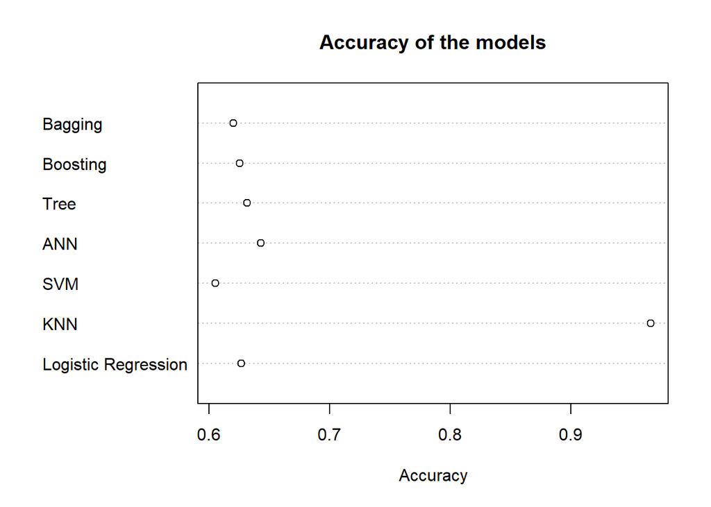

```r
Model =c("Logistic Regression", "KNN", "SVM", "ANN",
                                 "Tree", "Boosting", "Bagging")
Accuracy_Rate = c(glm_acc, knn_acc, svm_acc, ann_acc,
                                          tree_acc, boost10_acc, bag_acc)
dotchart(Accuracy_Rate, labels = Model, main = "Accuracy of the models", xlab = "Accuracy")
```

Only KNN produces a high accuracy rate while others remain at about 60%. So, we believe that stacking the models using trees will produce a better accuracy rate.

```r
#Preparing Dataset

PredictedTr <- data.frame(glm_tr, knn_tr, svm_tr, ann_tr,
                        tree_tr, boost10_tr, bag_tr)

Predicted <- data.frame(glm_pred, knn_pred, svm_pred, ann_pred,
                        tree_pred, boost10_pred, bag_pred)
library(C50)
stacked<- C5.0(PredictedTr[-ncol(PredictedTr)],train$AdoptionSpeed, trials = 5)

names(Predicted)<- names(PredictedTr)
stacked_pred<-predict(stacked, Predicted)

stacked_acc<- mean(stacked_pred == test_labels)
stacked_acc
```

```
## [1] 0.9663221
```

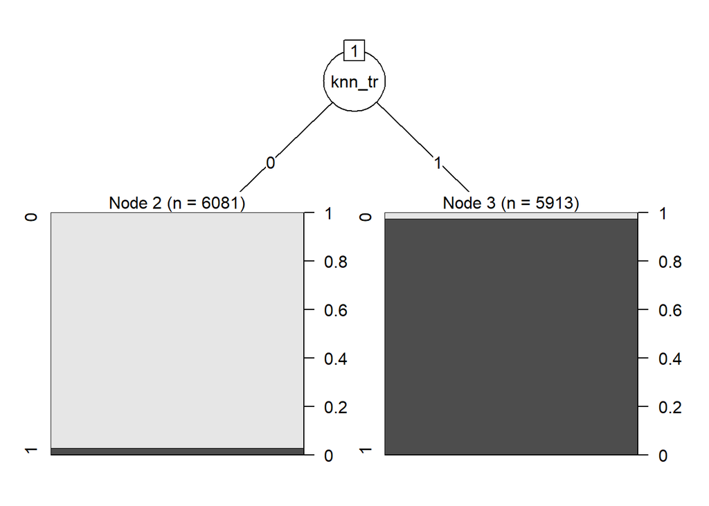

```r
plot(stacked)
```

The accuracy rate of this stacked model is 0.9663221 which is not an improvement from the previously highest accuracy rate, KNN’s (0.9663221). This is expected because there is little room for improvements in the higher 90% range.

## Conclusion

We have predicted whether a pet gets adopted within a month (31 days) or not using 8 models. The accuracy rate are as followed:

```r
Accuracy<-data.frame( "Model" =c("Logistic Regression", "KNN", "SVM", "ANN",
                                 "Tree", "Boosting", "Bagging", "Stacked Model" ),
                      "Accuracy Rate" = c(glm_acc, knn_acc, svm_acc, ann_acc,
                                          tree_acc, boost10_acc, bag_acc, stacked_acc))

Accuracy
```

```
##                 Model Accuracy.Rate
## 1 Logistic Regression     0.6268756
## 2                 KNN     0.9663221
## 3                 SVM     0.6055352
## 4                 ANN     0.6432144
## 5                Tree     0.6318773
## 6            Boosting     0.6255418
## 7             Bagging     0.6205402
## 8       Stacked Model     0.9663221
```

We can use the stacked model to predict the adoption speed have the best accuracy, along with the KNN model. With around 96% accuracy on the testing set, we are sure that this model can help animal shelters around the world in getting stray animals get adopted with in their best condition. Predicting the pet’s adoption speed will benefit companies in terms of resources optimization. This includes pets’ medical appointments with veterinarians. If they know how long will a pet be adopted, they can budget the food distribution, manage spaces for the pets and if they should place more pets for adoption.

There are limitations in our studies. For example, the original data also comes with photos of pets. We believe future studies including computer vision technologies can further help with the prediction.

We hope our efforts can help the global efforts to encourge more people to stay at home to enjoy time with their pets!